# Hard Work 1

## Instructions

1. Study Sections 1-5 of Chapter 1 – “Linear Regression with One Predictor Variable.”  
   (You may also choose to study Sections 6-8 if you are interested in the theory behind regression.)
2. Attempt and submit at least {24} Hard Work Points by Saturday at 11:59 PM.  
   Over {30} gets you {+1} Final Exam Point.  
   Over {40} gets you {+2} Final Exam Points.  
   Over {50} gets you {+3} Final Exam Points.

{…} are “Recommended” and will earn you the minimum points required.

{…} are optional, but the more of these you complete, the better.

The format of reporting your score on each problem is:

**{ Earned Points / Attempted Points }**

- **Attempted Points**: You gave the problem your time and energy, but aren’t sure if you are completing the problem correctly or not.
- **Earned Points**: You are confident you have completed the problem correctly by comparing your work to the [Student Solutions](https://byui.brightspace.com/d2l/common/dialogs/quickLink/quickLink.d2l?ou=358268&type=content&rcode=byui_production-1198908), other students in class, or the examples in the book. This should always be less than or equal to **Attempted Points**.

## Reading Points {21} Possible

### Problem 1 {3}{ 3/3 }

Recreate this chalkboard in your own handwriting

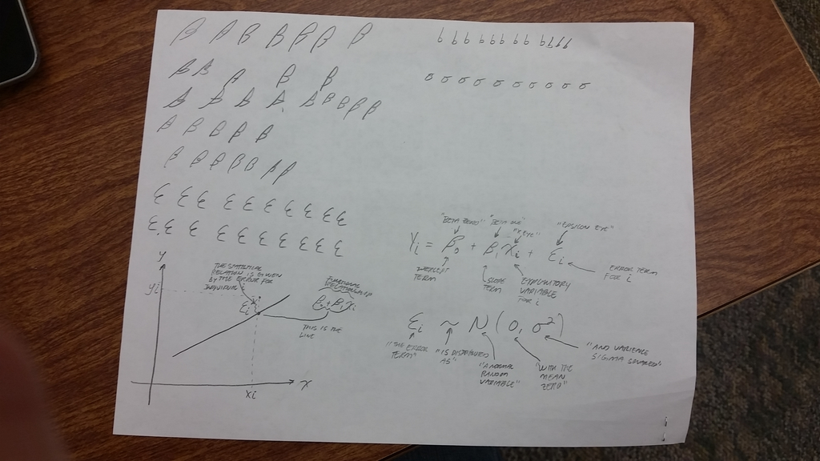

### Problems 1.29 and 1.30 {2}{ / }

### Problem 1.32 {2}{ / }

### Problem 1.33 {4}{ / }

### Problem 1.34 {3}{ / }

## Application Points {19} Possible

[Download Data Files](http://www.stat.ufl.edu/~rrandles/sta4210/Rclassnotes/data/textdatasets/index.html)

### Problem 1.19 {4}{ 4/4 }

```r
# Load the Problem 1.19 Data into the object "p1.19":
p1.19 <- read.table("https://netfiles.umn.edu/users/nacht001/www/nachtsheim/Kutner/Chapter%20%201%20Data%20Sets/CH01PR19.txt")

# Rewrite the column names to be "Y" and "X" to match the textbook:

colnames(p1.19) <- c("Y","X")

#p1.19 <- p1.19[c("X","Y")]

mylm <- lm(Y~X, data = p1.19)

summary(mylm)
```

```
##
## Call:
## lm(formula = Y ~ X, data = p1.19)
##
## Residuals:
##      Min       1Q   Median       3Q      Max
## -2.74004 -0.33827  0.04062  0.44064  1.22737
##
## Coefficients:
##             Estimate Std. Error t value Pr(>|t|)
## (Intercept)  2.11405    0.32089   6.588  1.3e-09 ***
## X            0.03883    0.01277   3.040  0.00292 **
## ---
## Signif. codes:  0 '***' 0.001 '**' 0.01 '*' 0.05 '.' 0.1 ' ' 1
##
## Residual standard error: 0.6231 on 118 degrees of freedom
## Multiple R-squared:  0.07262,    Adjusted R-squared:  0.06476
## F-statistic:  9.24 on 1 and 118 DF,  p-value: 0.002917
```

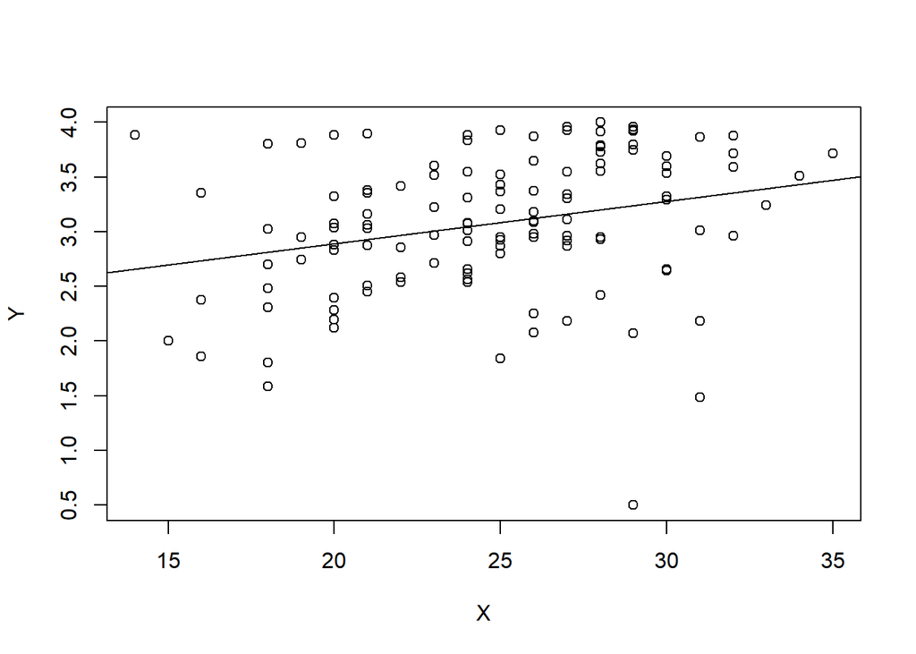

```r
plot(Y~X, data = p1.19)
abline(mylm)
```

```r
#b <- coef(mylm)

#b[1]+b[2]X

print(mylm$coefficients)
```

```
## (Intercept)           X
##  2.11404929  0.03882713
```

beta0 = 2.11405

beta1 = 0.03883

Yhat = 2.11405 + 0.038827X

4. 0.038827

```r
18.9754 +(1.8704*30)
```

```
## [1] 75.0874
```

### Problem 1.20 {4}{ 4/4 }

a, b

```r
# Load the Data:
p1.20 <- read.table("https://netfiles.umn.edu/users/nacht001/www/nachtsheim/Kutner/Chapter%20%201%20Data%20Sets/CH01PR20.txt")

# Rewrite the column names to be "Y" and "X" to match the textbook:
colnames(p1.20) <- c("Y","X")

#p1.20 <- p1.20[c("X","Y")]


lm20 <- lm(Y~X, data = p1.20)

print(lm20$coefficients)
```

```
## (Intercept)           X
##  -0.5801567  15.0352480
```

```r
summary(lm20)
```

```
##
## Call:
## lm(formula = Y ~ X, data = p1.20)
##
## Residuals:
##      Min       1Q   Median       3Q      Max
## -22.7723  -3.7371   0.3334   6.3334  15.4039
##
## Coefficients:
##             Estimate Std. Error t value Pr(>|t|)
## (Intercept)  -0.5802     2.8039  -0.207    0.837
## X            15.0352     0.4831  31.123   <2e-16 ***
## ---
## Signif. codes:  0 '***' 0.001 '**' 0.01 '*' 0.05 '.' 0.1 ' ' 1
##
## Residual standard error: 8.914 on 43 degrees of freedom
## Multiple R-squared:  0.9575, Adjusted R-squared:  0.9565
## F-statistic: 968.7 on 1 and 43 DF,  p-value: < 2.2e-16
```

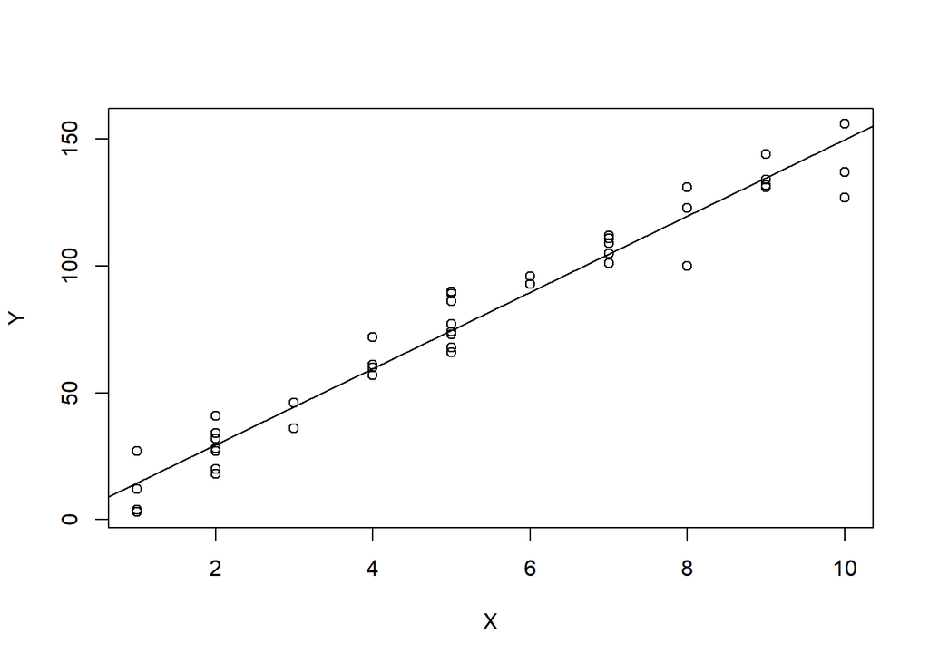

```r
plot(Y~X, data = p1.20)
abline(lm20)
```

3. beta0 is a negative number and is irrelevant because it represents the y-intercept and it’s impossible to fix a negative number of printers. Therefore, it’s irrelevant. d

```r
b <- lm20$coefficients

print(b[1] + (b[2]*5))
```

```
## (Intercept)
##    74.59608
```

### Problem 1.21 {4}{ 4/4 }

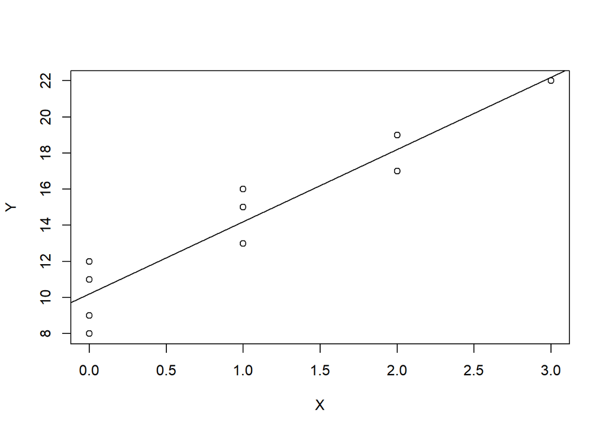

```r
# Load the Data:
p1.21 <- read.table("https://netfiles.umn.edu/users/nacht001/www/nachtsheim/Kutner/Chapter%20%201%20Data%20Sets/CH01PR21.txt")

# Rewrite the column names to be "Y" and "X" to match the textbook:
colnames(p1.21) <- c("Y","X")


#p1.21 <- p1.21[c("X","Y")]


plot(Y~X, data = p1.21)


lm21 <- lm(Y~X, data = p1.21)

abline(lm21)
```

```r
c <- lm21$coefficients
```

y=10.2 + 4.0X

```r
print(c)
```

```
## (Intercept)           X
##        10.2         4.0
```

```r
c[1]+(c[2]*1)
```

```
## (Intercept)
##        14.2
```

### Problem 1.22 {3}{ 2/3 }

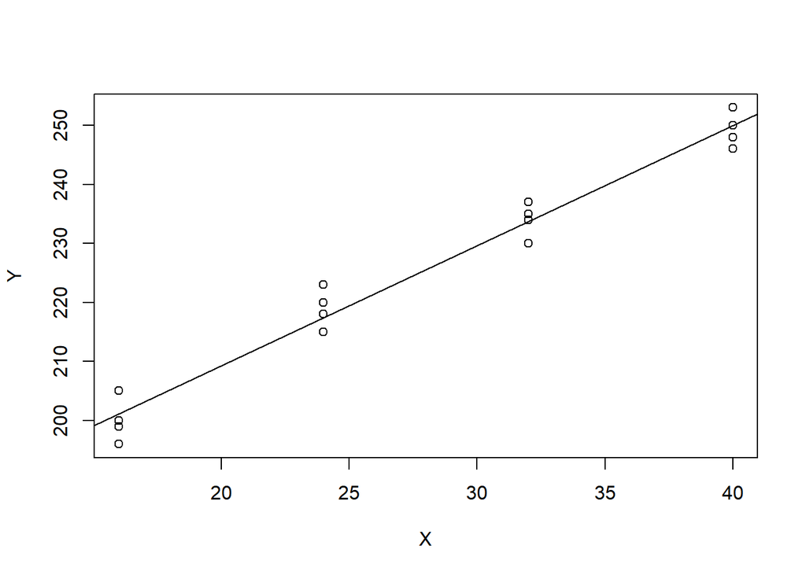

```r
# Load the Data:
p1.22 <- read.table("https://netfiles.umn.edu/users/nacht001/www/nachtsheim/Kutner/Chapter%20%201%20Data%20Sets/CH01PR22.txt")

# Rewrite the column names to be "Y" and "X" to match the textbook:
colnames(p1.22) <- c("Y","X")

#p1.22 <- p1.22[c("X","Y")]

plot(Y~X, data = p1.22)

lm22 <- lm(Y~X, data= p1.22)

abline(lm22)
```

```r
print(lm22$coefficients)
```

```
## (Intercept)           X
##  168.600000    2.034375
```

```r
d <- lm22$coefficients

print(d[1]+(d[2]*40))
```

```
## (Intercept)
##     249.975
```

```r
print(d[2])
```

```
##        X
## 2.034375
```

### Problem 1.27 {2}{ 1/2 }

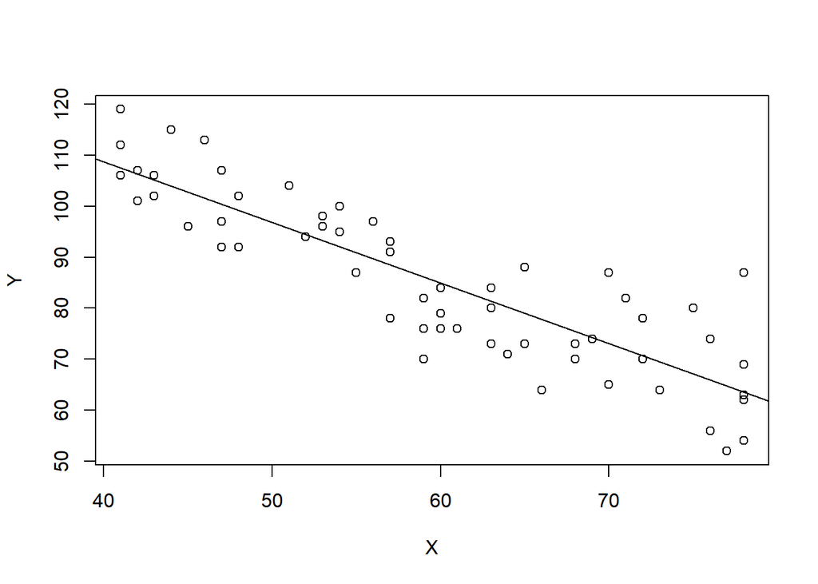

```r
# Load the Data:
p1.27 <- read.table("https://netfiles.umn.edu/users/nacht001/www/nachtsheim/Kutner/Chapter%20%201%20Data%20Sets/CH01PR27.txt")

# Rewrite the column names to be "Y" and "X" to match the textbook:
colnames(p1.27) <- c("Y","X")

#p1.27 <- p1.27[c("X","Y")]

plot(Y~X, data = p1.27)

lm27 <- lm(Y~X, data = p1.27)

abline(lm27)
```

```r
print(lm27$coefficients)
```

```
## (Intercept)           X
##  156.346564   -1.189996
```

yi = 156.3465 -1.1899Xi

```r
156.3465 +( -1.1899 * 41)
```

```
## [1] 107.5606
```

### Problem 1.28 {2}{ / }

```r
# Load the Data:
p1.28 <- read.table("https://netfiles.umn.edu/users/nacht001/www/nachtsheim/Kutner/Chapter%20%201%20Data%20Sets/CH01PR28.txt")

# Rewrite the column names to be "Y" and "X" to match the textbook:
colnames(p1.28) <- c("Y","X")
```